# Box Plots and Violin Plots

```python
import matplotlib.pyplot as plt
import pandas as pd
import seaborn as sns
sns.set(style="whitegrid")
```

## Box Plots

Example dataframe

```python
df1 = pd.DataFrame([10,15,20,25,30,50,60,80,90,160], columns=['value'])
```

```python
df1
```

|  | value |
| --- | --- |
| 0 | 10 |
| 1 | 15 |
| 2 | 20 |
| 3 | 25 |
| 4 | 30 |
| 5 | 50 |
| 6 | 60 |
| 7 | 80 |
| 8 | 90 |
| 9 | 160 |

```python
df1.describe()
```

|  | value |
| --- | --- |
| count | 10.000000 |
| mean | 54.000000 |
| std | 46.296148 |
| min | 10.000000 |
| 25% | 21.250000 |
| 50% | 40.000000 |
| 75% | 75.000000 |
| max | 160.000000 |

- The 25% value is known as **first quartile** or $Q1$.
- The 50% value is known as **median** or **second quartile** or $Q2$.
- The 75% value is known as **third quartile** or $Q3$.

When visualised as a boxplot, the quartiles together with the minimum and the maximum values provide an insight into the distribution of numerical data, its skewness and the presence of outliers.

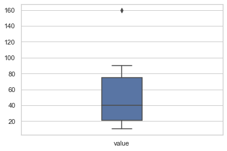

```python
sns.boxplot(data=df1, orient='v', width=0.2)
plt.show()
```

The box in a boxplot extends from $Q1$ to $Q3$. It is known as interquartile range (IQR). Any values smaller than $Q1-1.5*(Q3-Q1)$ or larger than $Q3+1.5*(Q3-Q1)$ are considered *outliers* and are drawn as separate dots. The two whiskers extend from $Q1$ and $Q3$ to the smallest and the largest values within $1.5*(Q3-Q1)$, respectively.

## Violin Plots

Violin plots are similar to box plots. They do not highlight the outliers but in addition to boxplots they visualise the density of the distribution of quantitative data.

```python
df2 = pd.DataFrame([10,15,20,25,26,27,27,28,29,30,31,32,41,42,43,43,45,70,72,75,78,79,80,90,160], columns=['value'])
```

Let's examine the box plot for **df2** first.

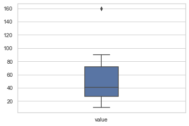

```python
sns.boxplot(data=df2, orient='v', width=0.2)
plt.show()
```

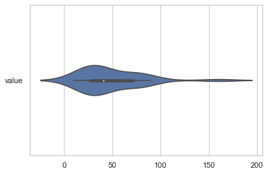

```python
sns.violinplot(data=df2, orient='h', width=0.2)
plt.show()
```